# Group Normalization for Genomic Data

https://groupnorm.netlify.app/_gn4gd_analysis

[Francois Collin](https://www.linkedin.com/in/francoisz/) with much revised input from claude.ai 3.7

September 20, 2025

- We are interested in learning about the preprocessing step referred to as normalization in **Group Normalization for Genomic Data**, Ghandi and Beer 2012 [1]
- David 2006 [2] and Huber 2006 [3] offer an alternative procedurure and provide data and software to assess performance.

# 1 Introduction

## Home

## 1.1 Nucleosome Biology

### Home

### What are Nucleosomes?

- Nucleosomes are the fundamental unit of chromatin structure in eukaryotic cells.
- Each nucleosome consists of approximately 147 base pairs of DNA wrapped around an octamer of histone proteins (two copies each of H2A, H2B, H3, and H4).
- Nucleosomes are connected by “linker DNA” of variable length (typically 10-80 bp), creating a “beads-on-a-string” structure that represents the first level of DNA packaging in the nucleus.

### Why are they Important

Nucleosomes play critical roles in genome function:

- **Genome Accessibility**: Nucleosomes restrict access to the DNA they wrap, acting physical barriers to DNA-binding proteins. This affects all DNA-dependent processes including transcription, replication, and repair.
- **Transcriptional Regulation**: Nucleosome positioning at promoters and regulatory elements can determine whether transcription factors can access their binding sites, directly impacting gene expression.
- **Epigenetic Regulation**: Histone modifications on nucleosomes serve signals for recruiting chromatin-modifying enzymes and transcription factors.

### Positioning Patterns

Nucleosomes are not randomly distributed along the genome but show specific positioning patterns:

- **Nucleosome-Depleted Regions (NDRs)**: Typically found at active promoters, enhancers, and transcription termination sites. These regions allow transcription factors and the transcription machinery to access DNA.
- **Well-Positioned Nucleosomes**: The +1 nucleosome (immediately downstream of the transcription start site) and -1 nucleosome (upstream of the promoter) are often precisely positioned.
- **Phased Arrays**: Downstream of the +1 nucleosome, subsequent nucleosomes often form regular arrays with consistent spacing.
- **Sequence Preferences**: DNA sequence composition influences nucleosome formation, with some sequences (like poly(dA:dT) tracts) disfavoring nucleosome formation.

### yeast

- In yeast (*Saccharomyces cerevisiae*), a stereotypical nucleosome organization exists around gene promoters:
  - a nucleosome-depleted region (NDR) upstream of the transcription start site (TSS)
  - flanked by well-positioned -1 and +1 nucleosomes
  - followed by an array of regularly spaced nucleosomes over the gene body.

[figure not shown]

## 1.2 Study Design

### Home

### Assay Design

- **Experimental Assay (MNase-chip)**:
  - **Crosslinking**: Cells are treated with formaldehyde to crosslink DNA to histones, preserving nucleosome positions
  - **Nuclease Digestion**: Micrococcal nuclease (MNase) preferentially digests linker DNA between nucleosomes, leaving nucleosome-protected DNA intact
  - **DNA Isolation**: Nucleosome-protected DNA fragments (~147 bp) are purified
  - **Labeling and Hybridization**: The DNA labeled and hybridized to the tiling array

/

### Tiling Array Design

- High-density oligonucleotide microarrays with probes spaced at regular intervals across the genome
- For yeast studies like Lee et al. (2007) [4] Affymetrix arrays witr
  - ~2.6 million 25-bp oligonucleotide probes covering the entire yeast genome
- Each probe measures the abundance of DNA fragments that hybridize to it
  - includes targeted fragments which have the complementary sequence, and other fragments
  - each probe is different in terms of its response to the mix of on-target and off-target fragments in the hybridized samples.
    - See Figure 1 from paper

### Figure 1

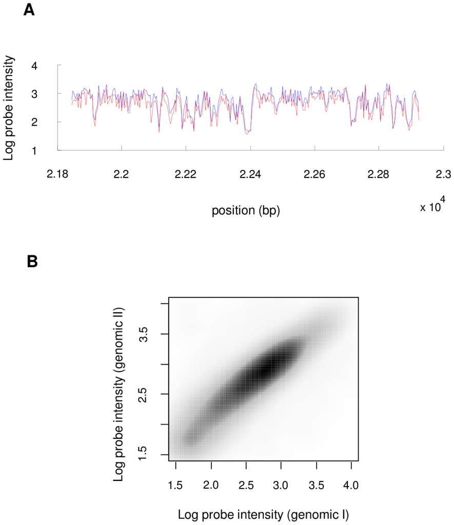

Figure 1. Genomic assays are often highly reproducible, but have significant efficiency variation across the genome.(A) Two genomic hybridization signals (biological replicates) from (Lee et al., 2007) shown along a portion of Car III are highly reproducible, but deviate significantly from the expected constant signal.(B) Across the whole genome, these variations are highly reproducible. Two genomic hybridizations for the entire yeast genome are highly correlated (Pearson C = 0.966). [^1]

```r
knitr::include_graphics("_GN4GD_analysis_figures/Fig001.png", dpi=200)
```

### Experimental Design

- A typical nucleosome positioning experimenting tiling arrays might include:
  - **Test samples**: samples bearing thee condition to be tested e.g., mutant strains, different growth conditions
  - **Reference Samples**: Genomic DNA samples to adjust or account for probe-specific effects
  - **Biological Replicates**: Multiple independent biological samples to assess reproducibility
  - **Controls**: Defined nucleosome with known attributes which can function as positive and negative controls. (e.g., +1 nucleosomes at well-studied genes)

## 1.3 David and Huber - Biology

- High-density oligonucleotide tiling arrays used for unbiased transcript mapping
- Detects expressed regions without relying on existing gene annotations
- Can identify novel transcripts, non-coding RNAs, and alternative splice variants
- Used for mapping transcriptomes in organisms like yeast

# 2 Implementation Details

## Home

## 2.1 Workflow

### Home

### Raw Data Look and QC

- Probe intensity values across the genome
- Substantial probe-to-probe variation due to sequence-specific hybridization differences
- Biological signal (nucleosome occupancy) superimposed on these technical variations

### Analysis Steps

- **Normalization**,: Correct for probe-specific effects (the focus of the Group Normalization method)
- **Smoothing**: Apply running average or other smoothing techniques to reduce noise
- **Peak Calling**: Identify nucleosome positions based on signal peaks
- **Comparativ Analysis**: Compare nucleosome positions between conditions

### Expected Patterns

- Regular oscillations in signal intensity with a periodicity of ~165 bp (nucleosome + linker)
- depletion of signal at promoters (NDRs)
- Well-defined peaks at +1 and -1 positions
- More variable positioning in gene bodies and intergenic regions

### Visualization

- Heatmaps aligned to TSSs showing nucleosome positioning across genes
- Average profiles showing nucleosome occupancy patterns around genomic features
- Gene-specific tracks showing nucleosome positions in regions of interest

## 2.2 Normalization

### Home

### Ghandi and Beer

- For each probe on the array, reference sample probe intensities are interrogated to form a *reference probe set*: a set of N = 1000 (a parameter) probes having similar intensities in the reference as the index probe.
- Using the reference probe sets, a reference set of test sample probe intensities is constructed for each probe on the array.
- With the reference set of test sample probe intensities define a mean for the low signal probes, $\mu_{i, low}$, and a mean for the high signal probes, $\mu_{i, high}$
  - for the nucleosome samples, $\mu_{i, low}$ is taken to bee the 30th percentile and $\mu_{i, high}$ the 70th percentile of he reference set of test sample probe intensities.
- If the test set probe intensity of a probe is $value$, the **group normalized value** is given by the following transformation:

$$\begin{equation}
\text{normalized value} = \frac{value - \mu_{low}}{\mu_{high} -
\mu_{low}}
\tag{1}
\end{equation}$$

- Can this transformation be optimized?
  - would think that the closer $\mu_{low}$ is to the probe effect for each probe, the better the correction would be
  - expect $\mu_{low}$ to be low variance but potentially high bias.
  - the denominator is just a change of units and is probably not needed.
    - the only tasks in this case is determining the presence of Nucleosiom or not.
- **Quantile-based Group Normalization**:, maps each probe to its rank or percentile in the comparable distribution.

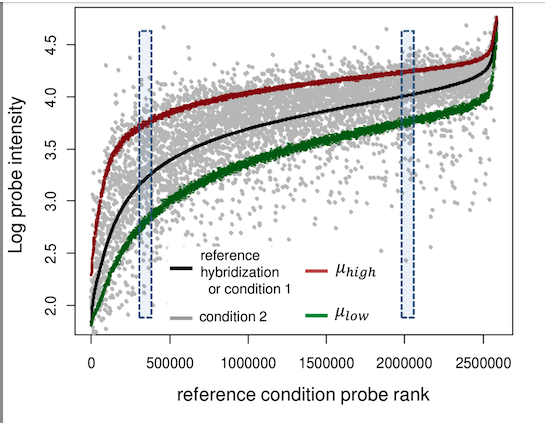

Figure 3 Overview of Group Normalization.Probes are shown sorted by on their values in a genomic hybridization (reference condition, black). For each probe, N = 1000 probes with closest signal in the genomic hybridization are assigned as reference set (dashed boxes) for each probe. Then high (red) and low (green) signal levels in the experimental condition (grey) are estimated from high and low probe signal ranges for each set of reference probes.

```r
knitr::include_graphics("_GN4GD_analysis_figures/Figure3A.png", dpi=125)
```

### Huber

1. DNA Reference Normalization (Their Main Method)
2. Perfect Match (PM) and Mismatch (MM) Probes
3. Statistical Normalization Methods

## 2.3 Assessment

### Home

### Ghandi and Beer

- The paper uses a **Signal Quality measure (in dB) to compare normalization methods:
  - Signal (S): Mean square change between conditions at significantly changed probes
  - Noise (N): Mean square difference between replicates
  - Signal Quality = 10 * log10(S/N)
- To identify significantly changed probes, the paper:
  1. Takes the top 2% of probes sorted by difference in signal between conditions
  2. Uses a 147bp spatial averaging window to focus on biologically relevant regions
  3. Takes the intersection of top probes identified by different methods to avoid bias

### Huber

# 3 Data Analysis ,,, TBC

# 4 References

1.

Ghandi, M., and Beer, M.A. (2012). [Group normalization for genomic data.](https://doi.org/10.1371/journal.pone.0038695) PLoS One *7*, e38695.

2.

David, L., Huber, W., Granovskaia, M., Toedling, J., Palm, C.J., Bofkin, L., Jones, T., Davis, R.W., and Steinmetz, L.M. (2006). A high-resolution map of transcription in the yeast genome. Proceedings of the National Academy of Sciences *103*, 5320–5325. Available at: https://doi.org/10.1073/pnas.0601091103.

3.

Huber, W., Toedling, J., and Steinmetz, L.M. (2006). Transcript mapping with high-density oligonucleotide tiling arrays. Bioinformatics *22*, 1963–1970. Available at: https://doi.org/10.1093/bioinformatics/btl289.

4.

Lee, W., Tillo, D., Bray, N., Morse, R.H., Davis, R.W., Hughes, T.R., and Nislow, C. (2007). A high-resolution atlas of nucleosome occupancy in yeast. Nature Genetics *39*, 1235–1244. Available at: https://doi.org/10.1038/ng2117.

[^1]: A better representation of reproducibility is provided by the [Bland–Altman plot](https://en.wikipedia.org/wiki/Bland%E2%80%93Altman_plot) or [MA plot](https://en.wikipedia.org/wiki/MA_plot).